# Weekly_Process_150622

Dohun Lee

2022-06-17

This is a RMDmarkdown to track and show progress between 15/06/22 ~ 22/06/22.

There were 4 main things to tackle:

1. liquidCNA not working for patients with two time samples.
   - TODO: try dummy column
2. liquidCNA for patients with 6+ time sample. Is there an alternative to calling subclonal segments (i.e., monotony)?
   - TODO: try splitting them. research monotony
3. Relative subclonal ratio:
   - TODO: tmp, divide by total number of sample rather than topSample
4. Understand inference of absolute subclonal ratio. estimateRGaussfit. How is absolute ratio calculated from relative ratio?
   - TODO: go function line by line. Histogram plot of seg.top.

# 1. Two time sample

There are 22 patients with two time samples:

```r
sample_num_patient <- sapply(1:80, function(x) length(bam_by_patient[[x]]))
two_samp_patients <- which(sample_num_patient == 2)

patient_ids[two_samp_patients] #patient ids of patients with two time samples
```

```
##  [1]  957 1333 2487 2511 2759 2788 2797 2802 2804 2825 2880 2948 2978 3240 3336
## [16] 3357 3391 3516 3521 3547 3806 4036
```

```r
table(sample_num_patient)
```

```
## sample_num_patient
##  2  3  4  5  8  9 10 11
## 22 34 14  3  2  2  1  2
```

**Currently, an error occurs at sample ordering and segmentation classification step., filterSegmentRatios().**

### alter filterSegmentRatios()

```r
  # Filter relative segment values (compared to baseline) to discard clonal (nonchanging) segments that stay relatively constant
  # Input:
  # - segs = normalised, purity-corrected segment-wise CN matrix, segments as rows, samples as columns
  # - cutOff = threshold value to determine whether a segment is varying enough to be not-clonal
  # - method = minmax or sd, evaluate segments based on their sd or minimum/maximum values in samples
  # Returns: a filtered set of a segments that have values exceeding the threshold

  filterSegmentRatios <- function(segs, cutOff, method, base=1){
    segsExtended <- cbind(segs, base) # add a further column, corresponding to the baseline
    if (!(method %in% c('minmax','sd'))){
      # if method is none of the supported ones, return the original
      print('Filtering criterion not recognised')
      return(segs)
    }
    if (method=='minmax'){
      # compute the minimal and maximal ratio in each segment, and return the ones that are far enough
      thresh.min <- 1-cutOff
      thresh.max <- 1+cutOff
      rat.max <- apply(segsExtended/base,1,max)
      rat.min <- apply(segsExtended/base,1,min)
      return(segs[(rat.max>thresh.max | rat.min<thresh.min),])
    }
    if (method=='sd'){
      # compute the standard deviation of each segment, and return the ones that are varied enough
      rat.sd <- apply(segsExtended,1,sd)
      if(nCol == 1){
        return(data.frame(Sample2 = segs[(rat.sd > cutOff),drop=F]))
      } else {
        return(segs[(rat.sd > cutOff),,drop=F])
      }
    }
  }
```

[output not shown]

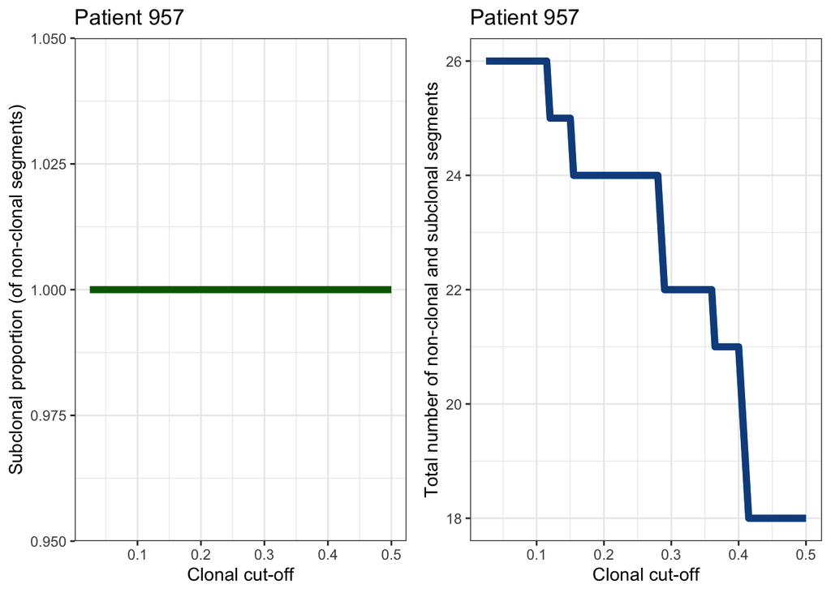

```r
fitInfo.df <- data.frame(cutOff = cutOffVec,
                         maxFit = sapply(fitInfo, function(x) x$max),
                         segsAboveCut = sapply(fitInfo, function(x) length(x$cons)),
                         segsInOrder = sapply(fitInfo, function(x) max(sapply(x$segs, length))))
p1 <- ggplot(fitInfo.df, aes(x=cutOff, y=maxFit)) + geom_line(size=2,colour='darkgreen') + theme_bw() +
  labs(x='Clonal cut-off',y='Subclonal proportion (of non-clonal segments)') +
  ggtitle(paste0('Patient ', patient_ids[p_num]))
p2 <- ggplot(fitInfo.df, aes(x=cutOff, y=segsAboveCut)) + geom_line(size=2,colour='deepskyblue3') +
  geom_line(aes(y=segsInOrder), size=2,colour='dodgerblue4') + theme_bw() +
  labs(x='Clonal cut-off',y='Total number of non-clonal and subclonal segments') +
  ggtitle(paste0('Patient ', patient_ids[p_num]))
grid.arrange(p1,p2,nrow=1)
```

For example, patient 957 has two time samples. Looking at the segment classification with the diagnostic plot, subclonal proportion is 1.0 for all cutOFF values. This would be the result of not being able to test for monotony with just one sample. As a result, recommended cutOff is always the lowest value tested (i.e. 0.025) - as it retains the most number of segments.

# 2. 6+ time sample

There are 7 patients with more than 6 time samples. They have the following number of time samples, respectively.

```r
timely_patients <- which(sample_num_patient > 6)
timely_bam_num <- sample_num_patient[timely_patients]

patient_ids[timely_patients] #patient ids of patients with 6+ time samples
```

```
## [1]  840 1439 2227 2789 3057 3068 3903
```

```r
timely_bam_num #number of time samples they have
```

```
## [1] 11 10  9  8 11  8  9
```

### Problem 1:

Patient 2789 has one erroneous time sample. As seen sample 7 has weird CN value. So this time sample was removed.

```r
seg.df <- read.delim(paste0("../DATA/2_QDNA_CNout/segment_2789_og", ".txt"))
cn.df <- read.delim(paste0("../DATA/2_QDNA_CNout/raw_cn_2789_og", ".txt"))

seg.df <- seg.df[,-(1:4)]
cn.df <- cn.df[,-(1:4)]

colnames(seg.df) <- paste0("Sample", 1:ncol(seg.df))
colnames(cn.df) <- paste0("Sample", 1:ncol(cn.df))

head(seg.df)
```

```
##   Sample1 Sample2 Sample3 Sample4 Sample5 Sample6  Sample7 Sample8
## 1   0.962   1.007   1.006    1.01    1.01   0.956 7176.137   1.003
## 2   0.962   1.007   1.006    1.01    1.01   0.956 7176.137   1.003
## 3   0.962   1.007   1.006    1.01    1.01   0.956 7176.137   1.003
## 4   0.962   1.007   1.006    1.01    1.01   0.956 7176.137   1.003
## 5   0.962   1.007   1.006    1.01    1.01   0.956 7176.137   1.003
## 6   0.962   1.007   1.006    1.01    1.01   0.956 7176.137   1.003
```

```r
head(cn.df)
```

```
##   Sample1 Sample2 Sample3 Sample4 Sample5 Sample6 Sample7 Sample8
## 1   0.873   0.999   1.017   1.093   0.975   0.841 2762265   1.040
## 2   0.965   0.981   0.969   1.029   1.052   0.838 7031989   1.028
## 3   0.984   1.026   1.009   0.987   1.018   1.009 2676455   0.966
## 4   0.952   1.061   0.969   1.058   0.984   0.834 1459381   1.000
## 5   0.910   1.001   0.920   0.985   1.081   1.026 2215307   1.090
## 6   0.939   0.987   1.092   0.994   0.960   0.983 3530624   1.043
```

```r
timely_bam_num[4] <- timely_bam_num[4] - 1 #remove sample7
```

### Coming back to the analysis…

Divide time samples into 2 batches with one overlap

```r
#divide time samples into 2 batches with one overlap
nbatch1 <- ceiling(timely_bam_num/2)
nbatch2 <- timely_bam_num - nbatch1
```

Run liquidCNA on both batches

```r
#initialise list to store results
timely_batch1_results <- vector(mode = "list", length = length(timely_patients))
timely_batch2_results <- vector(mode = "list", length = length(timely_patients))

#run liquidCNA on each batch
timely_batch1_results <- sapply(1:7,
                                simplify = FALSE,
                                function(x) run_liquidCNA( timely_patients[x],
                                                                timely = TRUE,
                                                                batch1 = TRUE,
                                                                nbatch = nbatch1[x]))

timely_batch2_results <- sapply(1:7,
                                simplify = FALSE,
                                function(x) run_liquidCNA( timely_patients[x],
                                                           timely = TRUE,
                                                           batch1 = FALSE,
                                                           nbatch = nbatch2[x]))

names(timely_batch1_results) <- timely_patients
names(timely_batch2_results) <- timely_patients
```

### Problem 2: How can we bring the two batch runs together?

Looking at the results of batch run for patient 840, it is seen that the sample order is no longer in the chronological order. Then, how can we bring the two batch runs together?

```r
load( "../DATA/timely_results.RData")
timely_batch1_results[[1]]
```

```
##      time          relratio purity_mean purity_median
## 6 Sample1                 0        0.21          0.21
## 4 Sample6 0.366846662806249       0.255         0.255
## 2 Sample4 0.392097485056158        0.15          0.15
## 1 Sample3 0.528103872639398       0.075         0.075
## 3 Sample5 0.559479305973358       0.085         0.085
## 5 Sample2                 1        0.05          0.05
```

```r
timely_batch2_results[[1]]
```

```
##       time          relratio purity_mean purity_median
## 6  Sample6                 0       0.255         0.255
## 2 Sample11 0.127852820721378        0.16          0.16
## 1 Sample10 0.271323830688926        0.14          0.14
## 4  Sample9 0.583539415197043       0.055         0.055
## 3  Sample7 0.755657311120086        0.05          0.05
## 5  Sample8                 1       0.055         0.055
```

### Try dividing into 2 batches of 7 (so that there is higher overlap)

```r
#divide time samples into 2 batches of 7 time samples
#here batch2 is set to 6 as sample number is +1ed in the code
nbatch1b <- 7
nbatch2b <- 6

#initialise list to store results
timely_batch1b_results <- vector(mode = "list", length = length(timely_patients))
timely_batch2b_results <- vector(mode = "list", length = length(timely_patients))

#run liquidCNA on each batch
timely_batch1b_results <- sapply(1:7,
                                simplify = FALSE,
                                function(x) run_liquidCNA( timely_patients[x],
                                                                timely = TRUE,
                                                                batch1 = TRUE,
                                                                nbatch = nbatch1b))

timely_batch2b_results <- sapply(1:7,
                                simplify = FALSE,
                                function(x) run_liquidCNA( timely_patients[x],
                                                           timely = TRUE,
                                                           batch1 = FALSE,
                                                           nbatch = nbatch2b))

#reorder samples so that they are increasing by relative ratio
timely_batch1b_results <- sapply(1:7, function(x)
  timely_batch1b_results[[x]][order(timely_batch1b_results[[x]]$relratio),],
  simplify = FALSE)

timely_batch2b_results <- sapply(1:7, function(x)
  timely_batch2b_results[[x]][order(timely_batch2b_results[[x]]$relratio),],
  simplify = FALSE)

names(timely_batch1b_results) <- timely_patients
names(timely_batch2b_results) <- timely_patients
```

```r
timely_batch1b_results[[1]]
```

```
##      time          relratio purity_mean purity_median
## 7 Sample1                 0        0.21          0.21
## 5 Sample6 0.338709124755433       0.255         0.255
## 3 Sample4 0.362023181473835        0.15          0.15
## 2 Sample3 0.487597731197346       0.075         0.075
## 4 Sample5 0.516566634668007       0.085         0.085
## 1 Sample2 0.923298912315096        0.05          0.05
## 6 Sample7                 1        0.05          0.05
```

```r
timely_batch2b_results[[1]]
```

```
##       time           relratio purity_mean purity_median
## 7  Sample5                  0       0.085         0.085
## 3  Sample6  0.068326589631717       0.255         0.255
## 1 Sample10 0.0713515519128379        0.14          0.14
## 2 Sample11  0.146583540368732        0.16          0.16
## 5  Sample9  0.629961228751868       0.055         0.055
## 4  Sample7  0.804182857397222        0.05          0.05
## 6  Sample8                  1       0.055         0.055
```

### only odd numbers

```r
#initialise list to store results
timely_batchc_results <- vector(mode = "list", length = length(timely_patients))

#run liquidCNA on each batch
timely_batchc_results <- sapply(1:7,
                                simplify = FALSE,
                                function(x) run_liquidCNA( timely_patients[x],
                                                                timely = TRUE,
                                                                batch1 = TRUE,
                                                                nbatch = NULL))
#reorder samples so that they are increasing by relative ratio
timely_batchc_results <- sapply(1:7, function(x)
  timely_batchc_results[[x]][order(timely_batchc_results[[x]]$relratio),],
  simplify = FALSE)
names(timely_batchc_results) <- timely_patients
```

```r
timely_batchc_results[[1]]
```

```
##       time          relratio purity_mean purity_median
## 6  Sample1                 0        0.07          0.07
## 1 Sample11 0.592151027953083        0.16          0.16
## 3  Sample5 0.681813248150023       0.085         0.085
## 2  Sample3 0.825046731570425       0.075         0.075
## 4  Sample9 0.921662853155748       0.055         0.055
## 5  Sample7                 1        0.05          0.05
```

# 3. Relative subclonal ratio

Solon suggested try dividing by total number of sample rather than topSample in estimateRSegmentRatio().

```
for (samp in toEstimate){
      tmp <- c()
      for (top in topSamples){

          tmp <- c(tmp,(seg.ratios[,samp])/(seg.ratios[,top]))
            #simple ratio of purity corrected CNs of segment
            # = (non-top-sample / top-sample)

          }
      final.ratios <- rbind(final.ratios, data.frame(value=tmp, variable=samp, weight=w))

  }
  return(final.ratios)
```

I think in the package CNs of segments are ratioed against topSample as it allows CN to be evaluated segment by segment. I am guessing that this will result less bias for extreme (large/small) dCN of some segments. Which must also be why they are doing medians > means as well.

```r
load("../DATA/eg_seg.dcn.toUse.RData")

#input into estimateRSegmentRatio()
#this is dCN of each segment between time sample n and base sample
#order of time sample is permutation w/ greatest number of subclonal segments
seg.dcn.toUse
```

```
##        Sample2     Sample3
## 1    1.3956149   1.7362611
## 2   -1.8375606  -2.6304825
## 5    1.0271219   1.0433362
## 6    1.6338532   1.8618028
## 8   -0.9876869  -1.4525811
## 9    0.9128151   1.5018453
## 14  -0.6068740  -0.9720338
## 18  -5.3428973  -6.0138137
## 20   0.7920583   0.8124452
## 23   1.5568952   2.3325102
## 24 -11.7741420 -11.7469387
## 28  -0.3003028  -0.8848688
## 31  -3.1653263  -3.7825229
## 33   1.1089072   1.5620681
## 36  -1.1427080  -1.1452124
## 37  -2.4028803  -2.8118792
## 42  -1.3113999  -1.4643289
## 43  -1.1150727  -2.1285361
```

```r
#Current liquidCNA
topSample <- names(seg.dcn.toUse)[ncol(seg.dcn.toUse)]
toEstimate <- setdiff(names(seg.dcn.toUse), c(topSample,baseSample))
final.ratios <- estimateRSegmentRatio(seg.dcn.toUse, toEstimate, topSample, 1)
final.medians <- aggregate(final.ratios$value,
                           by=list(final.ratios$variable), median)
final.medians
```

```
##   Group.1         x
## 1 Sample2 0.8203171
```

```r
#mean
mean(seg.dcn.toUse[,1])
```

```
## [1] -1.197755
```

```r
mean(seg.dcn.toUse[,2])
```

```
## [1] -1.343496
```

```r
mean(seg.dcn.toUse[,1]) / mean(seg.dcn.toUse[,2])
```

```
## [1] 0.8915208
```

```r
#median
median(seg.dcn.toUse[,1]/nrow(seg.dcn.toUse))
```

```
## [1] -0.04429336
```

```r
median(seg.dcn.toUse[,2]/nrow(seg.dcn.toUse))
```

```
## [1] -0.05881239
```

```r
median(seg.dcn.toUse[,1]/nrow(seg.dcn.toUse)) / median(seg.dcn.toUse[,2]/nrow(seg.dcn.toUse))
```

```
## [1] 0.7531297
```

Could explore how accurate this is with synthetic data. Additionally, this method will allow relative ratio to be found for two-sample-only patients (by comparing to base)

# 4. Absolute subclonal ratio

### estimateRGaussianFit()

Density of CNs of selected segments are thought as a mixture model of 5 CNs. A Gaussian mixture model is fitted for each sample’s segment dCNs. Absolute ratio is defined as the shared mean parameters.

Input:

```
estimateRGaussianFit <- function(seg.rel.toUse, topSample,
                                final.medians, gaussSigma=0.1, nStates=2,
                                lambdaOverwrite=0.2, verbose=F){
    seg.top <- seg.rel.toUse[,topSample]
    start <- mean(seg.top[seg.top<0])
      #average of deltaCNs of top sample that are negative

    if (is.nan(start)){
        # estimate the initial value for fitting from segments with DCN between 0 and 1
      start <- -1* mean(seg.top[seg.top>0 & seg.top<1])
  }
  if (is.nan(start)){
  # if no starting point can be found, start from a default of 25%
      start <- -0.25
  }

  # By default the following DCN values are used: -2, -1, 1, 2, 3
  mixfit <- normalmixEM(as.numeric(seg.top),
                        lambda=lambdaOverwrite,
                        mean.constr = c("2a","a","-a","-2a","-3a"),
                        mu=c(2,1,-1,-2,-3)*start,sigma=gaussSigma)
  # only return the obtained value if converged in less than 800 iterations
  if (length(mixfit$all.loglik)<800){
      final.medians$rat[final.medians$time==topSample] <- -1*(mixfit$mu[2])
      #sigma depends on the number of segments used and that depends on how many states they were distributed across
      final.medians$rat_sd[final.medians$time==topSample] <- (mixfit$sigma[1])/sqrt(nrow(seg.rel.toUse)/nStates)
  }
  if (verbose){
    print(mixfit$lambda)
  }
  return(final.medians)
}
```

### Density plot of segments’ dCNs

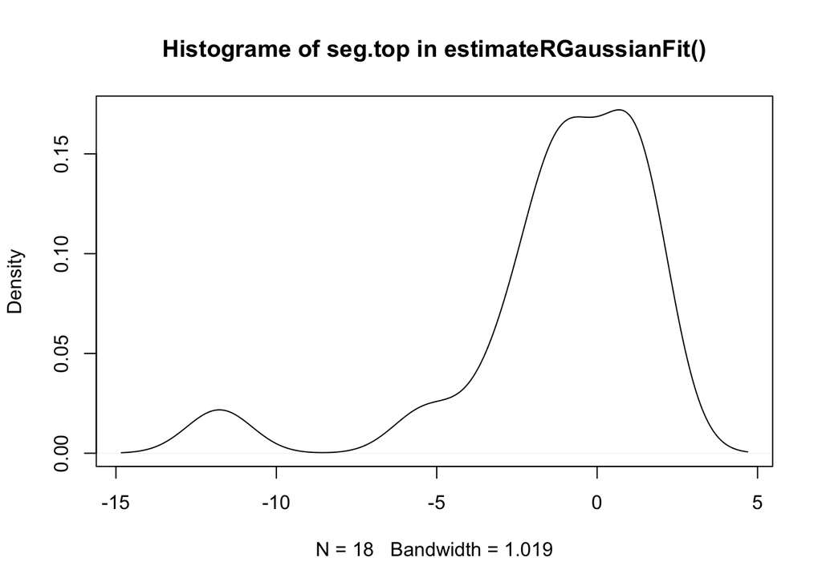

```r
#input into estimateRSegmentRatio()
plot(density(seg.dcn.toUse[,1]), main = "Histograme of seg.top in estimateRGaussianFit()")
```

### normalmixEM()

**normalmixEM(as.numeric(seg.top), lambda=lambdaOverwrite, mean.constr = c(“2a”,“a”,“-a”,“-2a”,“-3a”), mu=c(2,1,-1,-2,-3) x start,sigma=gaussSigma)**

Input:

- lambda: Initial value of mixing proportions. Automatically repeated as necessary to produce a vector of length k. **Default in the package is 0.2**
- mu: Starting value of vector of component means. **Default is (2,1,-1,-2,-3) x start**. This results *k*, number of components, to be set to 5. Question is why those five dCN states, and why is start the mean of negative dCNs?
- mean.constr: Equality constraints on the mean parameters *sigma: Starting values of components’ standard deviations

**Question regarding EM starting values** k, the number of mixture component, is set to 5 by default. The initial starting values of mean are set as (2,1,-1,-2,-3) x start where start is the mean of negative CNs.

### normalmixEM() for one time sample with liquidCNA defaults

```r
mixfit <- normalmixEM(as.numeric(seg.top),
                        lambda=lambdaOverwrite,
                        mean.constr = c("2a","a","-a","-2a","-3a"),
                        mu=c(2,1,-1,-2,-3)*start,sigma=gaussSigma)
```

```
## number of iterations= 390
```

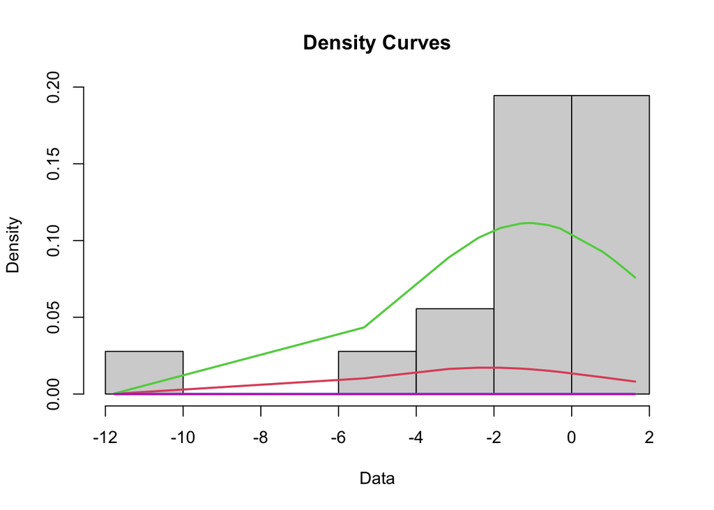

```r
plot(mixfit,which = 2)
```

```r
mixfit_res <- t(data.frame(lambda = mixfit$lambda, mu = mixfit$mu, mixfit$sigma))
mixfit_res
```

```
##                    [,1]       [,2]         [,3]         [,4]          [,5]
## lambda        0.1339017  0.8660983 1.600506e-27 4.990314e-77 7.438777e-156
## mu           -2.1686993 -1.0843496 1.084350e+00 2.168699e+00  3.253049e+00
## mixfit.sigma  3.1016941  3.1016941 3.101694e+00 3.101694e+00  3.101694e+00
```

### normalmixEM() for one time sample with mixtool defaults

```r
raw_mixfit <- normalmixEM(as.numeric(seg.top), k = 5)
```

```
## One of the variances is going to zero;  trying new starting values.
## One of the variances is going to zero;  trying new starting values.
## number of iterations= 21
```

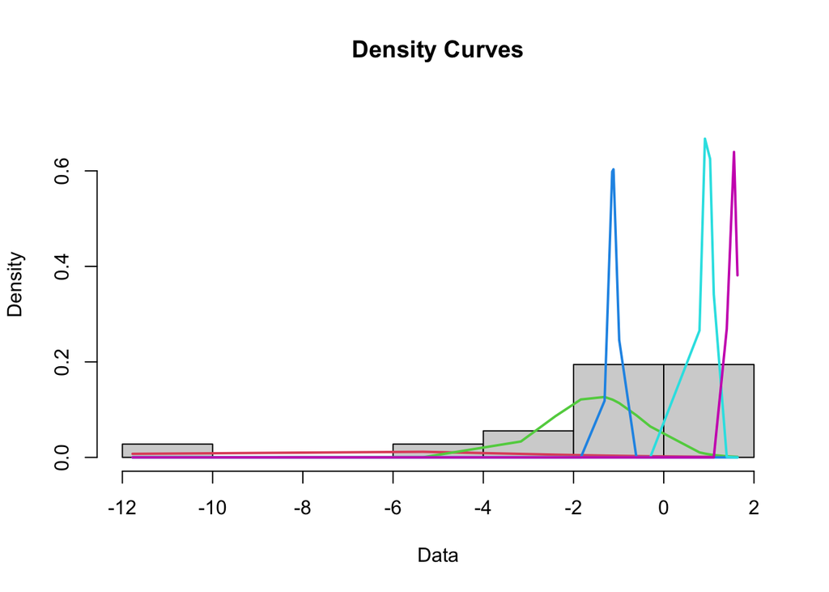

```r
plot(raw_mixfit, which = 2)
```

```r
raw_mixfit_res <- t(data.frame(lambda = raw_mixfit$lambda, mu = raw_mixfit$mu, raw_mixfit$sigma))
raw_mixfit_res
```

```
##                        [,1]       [,2]       [,3]      [,4]       [,5]
## lambda            0.1325785  0.3281552  0.1562288 0.2177106 0.16532682
## mu               -7.5015981 -1.4917786 -1.1257905 0.9617569 1.52923832
## raw_mixfit.sigma  3.8298995  1.0188233  0.1027421 0.1196910 0.09917449
```

TODO: figure out which patients result NA in absolute derivation and find pattern.

```r
# topSample = "Sample2"
# gaussSigma=0.1
# nStates=3
# lambdaOverwrite=0.2
# verbose=F
#
# seg.top <- seg.dcn.toUse[,topSample]
# start <- mean(seg.top[seg.top<0])
# start
#
# # By default the following DCN values are used: -2, -1, 1, 2, 3
# #function for fitting of mixture distributions
# mixfit <- normalmixEM(as.numeric(seg.top),
#                       lambda=lambdaOverwrite,
#                       mean.constr = c("2a","a","-a","-2a","-3a"),
#                       mu=c(2,1,-1,-2,-3)*start,
#                       sigma=gaussSigma)
# plot(mixfit,which = 2)
#
# mixfit2 <- normalmixEM(as.numeric(seg.top), k = 5)
# plot(mixfit2, which = 2)
```